# Proj2_EC425

Nathan Bracken

5/9/2022

```r
huai_df = here("data", "huairiver.dta") |> read_dta()
```

# fix charts

## Specific questions to address in your summary

1. Explain why a simple comparison of air pollution in northern cities versus southern cities would not measure the causal effect of the Huai River Policy. Explain how did the Ebenstein et al. paper overcome this problem by using a regression discontinuity design.

Ebstein et al overcame this problem by using a regression discontinuity design in order to try and make the assumption that the only difference between the two groups was the physical location on the either side of the boundry line to make them effectively barely treated.

2. Explain what is the outcome variable and what is the assignment variable in Fig.2 of the Ebenstein et al. paper?

The outcome variable in figure 2 is $PM_{10}$ micro grams per meters cubed. The assignment variable in figure 2 is Degrees north of the Huai river boundary. The outcome variable is a measure of the density of particulate matter in a given area and the assignment variable is the distance north and south of the river. The researchers are testing if there is an increase in particulate matter in the group on the north side of the river (with a positive count on the assignment variable) as compared to the group on the south side of the river (a negative count on the assignment variable).

3. What is a binned scatter plot? Explain how it is constructed. Hint: Binscatter plot is covered in week 1’s lecture.

A binned scatter plot is a scatter plot that consolidates the scatter points into groups based on a mean reporting metric rather than plotting each individual point.

4. Graphical regression discontinuity analysis.
1. Draw a binned scatter plot to visualize how PM10 changes at the Huai River line. Display fitted lines (linear, or quadratic, or whatever functional form you see fit) based on what you see in the data.

```r
# dist bin
huai_df = huai_df %>%
  mutate(dist_bin = cut(dist_huai,
                      breaks = quantile(dist_huai, probs = seq(0, 1, by = 0.05),
                      na.rm = TRUE)))
# Checking # bin obs
table(huai_df$dist_bin)
```

```
##
##   (-12.8,-9.01]   (-9.01,-7.77]    (-7.77,-6.5]    (-6.5,-5.29]    (-5.29,-4.1]
##               8               8               8               8               8
##    (-4.1,-3.24]   (-3.24,-2.17]   (-2.17,-1.78]   (-1.78,-1.07] (-1.07,-0.0471]
##               8               8               8               8               8
##   (-0.0471,1.4]      (1.4,2.24]     (2.24,3.15]     (3.15,3.89]     (3.89,5.29]
##               8               8               8               8               8
##     (5.29,6.83]     (6.83,7.71]     (7.71,9.29]     (9.29,12.4]     (12.4,16.5]
##               8               8               8               8               8
```

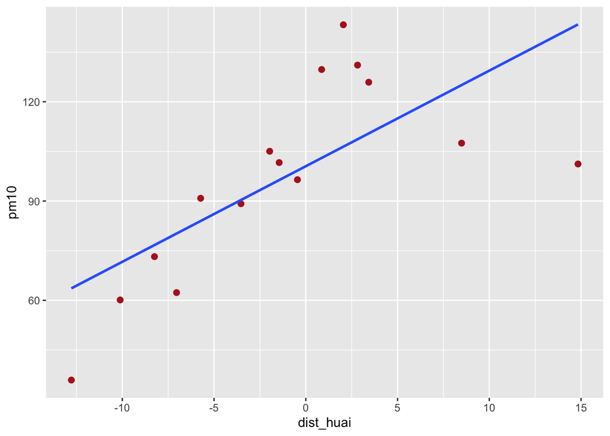

```r
huai_df %>%
group_by(dist_bin) %>%
summarise(dist_huai = mean(dist_huai), pm10 = mean(pm10)) %>%
ggplot(aes(x = dist_huai, y = pm10)) +
geom_point(colour = "firebrick", size = 2, alpha = 1) +
geom_smooth(method = "lm", se = FALSE)
```

b. Draw binned scatter plots to test whether (i) temperature, (ii) precipitation, and (iii) wind speed changes at the Huai River line. Display fitted lines (linear, or quadratic, or whatever functional form you see fit) based on what you see in the data.

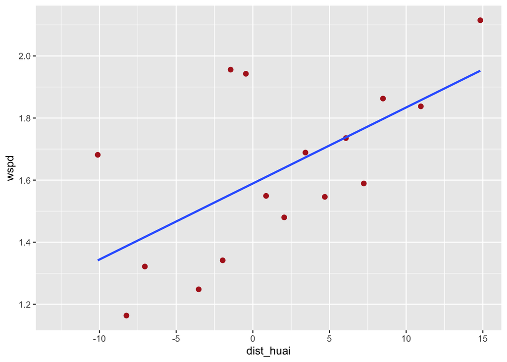

```r
huai_df %>%
group_by(dist_bin) %>%
summarise(dist_huai = mean(dist_huai), wspd = mean(wspd)) %>%
ggplot(aes(x = dist_huai, y = wspd)) +
geom_point(colour = "firebrick", size = 2, alpha = 1) +
geom_smooth(method = "lm", se = FALSE)
```

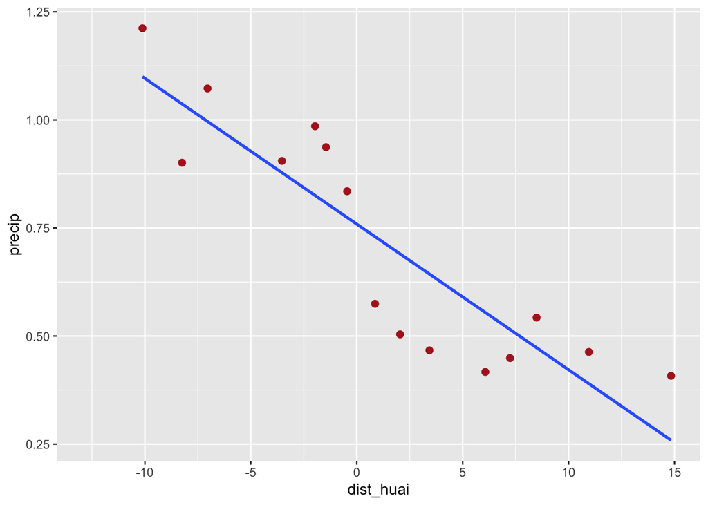

```r
huai_df %>%
group_by(dist_bin) %>%
summarise(dist_huai = mean(dist_huai), precip = mean(prcp)) %>%
ggplot(aes(x = dist_huai, y = precip)) +
geom_point(colour = "firebrick", size = 2, alpha = 1) +
geom_smooth(method = "lm", se = FALSE)
```

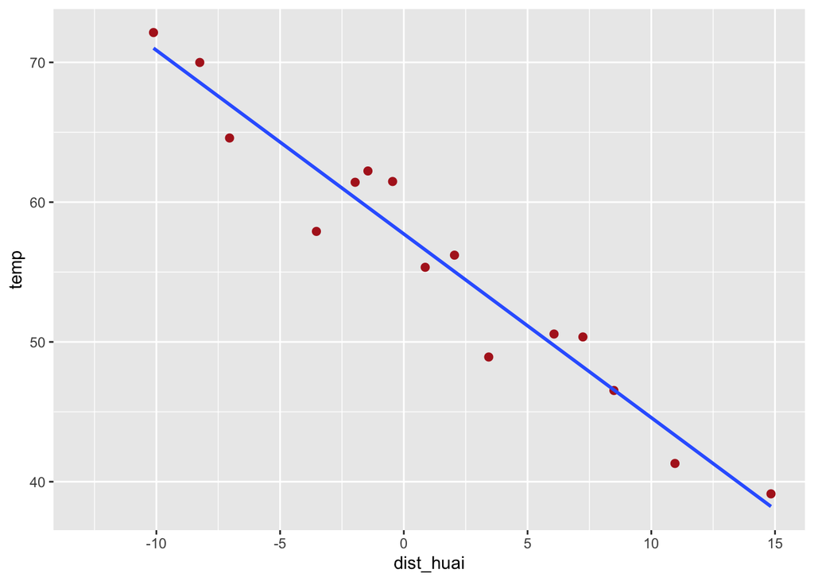

```r
huai_df %>%
group_by(dist_bin) %>%
summarise(dist_huai = mean(dist_huai), temp = mean(temp)) %>%
ggplot(aes(x = dist_huai, y = temp)) +
geom_point(colour = "firebrick", size = 2, alpha = 1) +
geom_smooth(method = "lm", se = FALSE)
```

5. Regression analysis. Run the regressions that correspond to your three graphs in 4a and 4b to quantify the discontinuities that you see in the data. Report a 95% confidence interval for each of these estimates.  
   Note: Part of this question is to get you to think about how to do bandwidth selection in a regression discontinuity design. Carefully read through how Ebenstein et al. choose 2 bandwidth (e.g., page 4 of the paper) and the associated material in the SI Appendix. Try your best to replicate their bandwidth selection in your work.

```r
# Specifying regression models
lm1 = rdrobust(y = huai_df$pm10, x = huai_df$dist_huai, all = TRUE)
lm2 = rdrobust(huai_df$wspd, huai_df$dist_huai, all = TRUE)
lm3 = rdrobust(huai_df$temp, huai_df$dist_huai, all = TRUE)
lm4 = rdrobust(huai_df$prcp, huai_df$dist_huai, all = TRUE)

summary(lm1)
```

```
## Call: rdrobust
##
## Number of Obs.                  154
## BW type                       mserd
## Kernel                   Triangular
## VCE method                       NN
##
## Number of Obs.                   80           74
## Eff. Number of Obs.              47           37
## Order est. (p)                    1            1
## Order bias  (q)                   2            2
## BW est. (h)                   5.268        5.268
## BW bias (b)                   7.995        7.995
## rho (h/b)                     0.659        0.659
## Unique Obs.                      80           74
##
## =============================================================================
##         Method     Coef. Std. Err.         z     P>|z|      [ 95% C.I. ]
## =============================================================================
##   Conventional    50.197    14.492     3.464     0.001    [21.792 , 78.602]
## Bias-Corrected    54.412    14.492     3.754     0.000    [26.007 , 82.816]
##         Robust    54.412    15.702     3.465     0.001    [23.637 , 85.187]
## =============================================================================
```

```r
summary(lm2)
```

```
## Call: rdrobust
##
## Number of Obs.                  156
## BW type                       mserd
## Kernel                   Triangular
## VCE method                       NN
##
## Number of Obs.                   78           78
## Eff. Number of Obs.              31           20
## Order est. (p)                    1            1
## Order bias  (q)                   2            2
## BW est. (h)                   3.125        3.125
## BW bias (b)                   4.655        4.655
## rho (h/b)                     0.671        0.671
## Unique Obs.                      78           78
##
## =============================================================================
##         Method     Coef. Std. Err.         z     P>|z|      [ 95% C.I. ]
## =============================================================================
##   Conventional    -0.447     0.377    -1.185     0.236    [-1.187 , 0.292]
## Bias-Corrected    -0.416     0.377    -1.103     0.270    [-1.156 , 0.323]
##         Robust    -0.416     0.444    -0.937     0.349    [-1.287 , 0.455]
## =============================================================================
```

```r
summary(lm3)
```

```
## Call: rdrobust
##
## Number of Obs.                  153
## BW type                       mserd
## Kernel                   Triangular
## VCE method                       NN
##
## Number of Obs.                   76           77
## Eff. Number of Obs.              38           29
## Order est. (p)                    1            1
## Order bias  (q)                   2            2
## BW est. (h)                   3.699        3.699
## BW bias (b)                   5.970        5.970
## rho (h/b)                     0.620        0.620
## Unique Obs.                      76           77
##
## =============================================================================
##         Method     Coef. Std. Err.         z     P>|z|      [ 95% C.I. ]
## =============================================================================
##   Conventional    -5.447     5.663    -0.962     0.336   [-16.547 , 5.653]
## Bias-Corrected    -5.409     5.663    -0.955     0.340   [-16.509 , 5.691]
##         Robust    -5.409     7.215    -0.750     0.453   [-19.550 , 8.732]
## =============================================================================
```

```r
summary(lm4)
```

```
## Call: rdrobust
##
## Number of Obs.                  153
## BW type                       mserd
## Kernel                   Triangular
## VCE method                       NN
##
## Number of Obs.                   76           77
## Eff. Number of Obs.              40           29
## Order est. (p)                    1            1
## Order bias  (q)                   2            2
## BW est. (h)                   3.861        3.861
## BW bias (b)                   6.204        6.204
## rho (h/b)                     0.622        0.622
## Unique Obs.                      76           77
##
## =============================================================================
##         Method     Coef. Std. Err.         z     P>|z|      [ 95% C.I. ]
## =============================================================================
##   Conventional    -0.271     0.070    -3.855     0.000    [-0.408 , -0.133]
## Bias-Corrected    -0.269     0.070    -3.825     0.000    [-0.406 , -0.131]
##         Robust    -0.269     0.083    -3.238     0.001    [-0.431 , -0.106]
## =============================================================================
```

6. Recall that any quasi experiment requires an identification assumption to make it as good as an experiment. What is the identification assumption for regression discontinuity design? Explain whether your graphs in 4b are consistent with that assumption.

The identification assumption for regression discontinuity design is the covariate smoothness test. My graphs in 4b are consistent with the assumption that the cutoff does not contribute to some change in the outcome variable. We do not see any large jumps in the data in any of the charts except for possibly precipitation.

7. Another type of validity test for regression discontinuity design is the manipulation test. Do we need to worry about manipulation in this study context? Explain why or why not. If you believe a manipulation test should be done, report such a test.

We do not need to worry about manipulation in this context because the treatment group was assigned treatment based upon their location in reference to the river and people were not allowed to move to receive coal. A manipulation test would tell us if people are further from the cutoff, they have a smaller chance of receiving the treatment. The line between treatment and not treatment is very clear.

8. Consider the “placebo test” in Fig. 4 of the Ebenstein et al. paper.
1. Explain the logic of the “placebo test” underlying Fig. 4. Why did the authors estimate regression discontinuity using false locations of the Huai River? What do the results of this test tell us?
2. Replicate Fig. 4 of Ebenstein et al. (2017). Hint: To obtain cities’ distance to a “placebo” Huai River that is 1-degree North of the true Huai River, simply add 1 to the “dist_huai” variable.

For the placebo test, the authors estimated regressions by falsely placing the huai river at different distances north and south of the actual Huai river. The authors wanted to test to see if their were statistically significant life expectancy outcomes in other places if the river would have been there to estimate some sort of “spurious” relationship between locations. By doing so, they can see if the Huai river is actually the cutoff between the two groups with the coal being the treatment that makes the difference in the life expectancy.

```r
p_tib = map_dfr(.x = -5:5, .f = function(i){
   rdrob = rdrobust(y = huai_df$pm10, x = huai_df$dist_huai, c = i, h = 5)
      tibble(
      cutoff = i,
      estimate = rdrob$coef[1],
      std.error = rdrob$se[1],
      ci_low = estimate - 1.96 * std.error,
      ci_high = estimate + 1.96 * std.error
    )
})
```

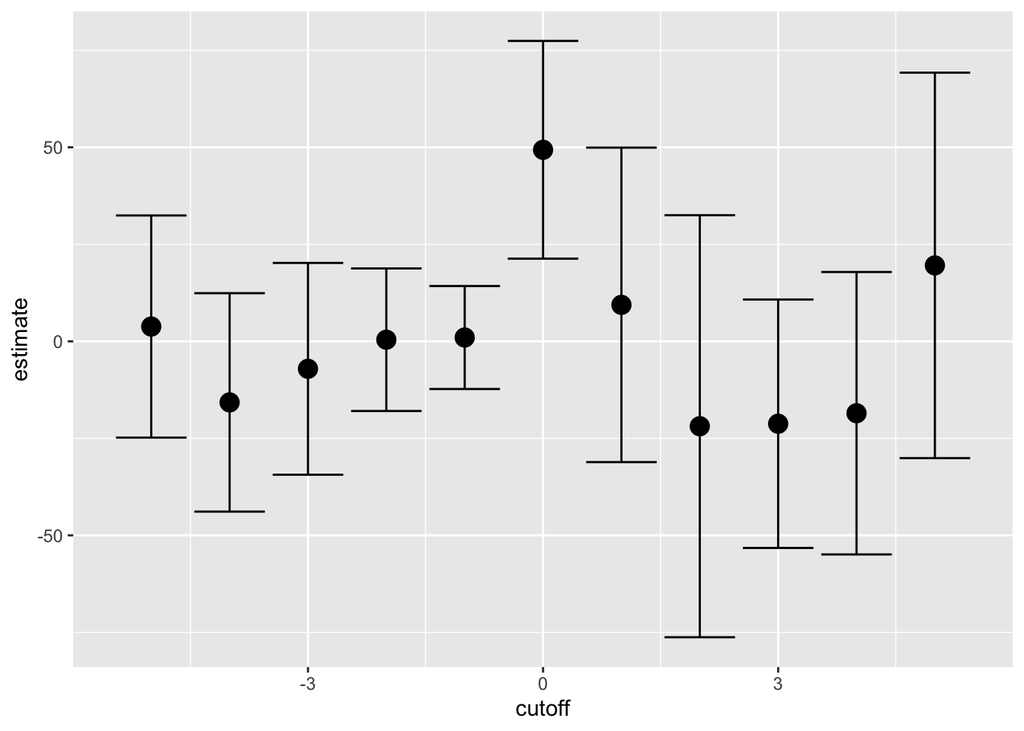

```r
ggplot(data = p_tib, aes(x = cutoff, y = estimate)) +
    geom_point(size = 4) +
    geom_errorbar(aes(ymax = ci_high, ymin = ci_low))
```